# Analyzing metrics of ecological specialization and interaction turnover

## Step 4: Prepare results for reporting and interpretation

**Create model summaries, calculate confidence intervals, and tidy results into dataframe for export**

```r
#Will also add information about sample size: total # of observations (rows), number of levels per random effect, and the number of replicates (split into 'control' vs. 'treatment')
results <- models %>%
  mutate(summary = map(model, summary),
         summary_tidy = map(model, broom.mixed::tidy),
         confint_wald = map(model, ~calculate_ci(., method_name = "wald"))) %>%
  mutate(num_obs = map(model, get_number_obs),
         num_levels = map(model, get_number_re_levels),
         num_reps = map(data, ~get_sample_size(data = ., vars = c("year", "patch", "control_treatment"), grouping_var = "control_treatment")))

#Columns to keep when extract the results
col_names <- c("model_number", "analysis", "sampling_method", "bird_group", "subanalysis", "yvar")

#Extract model summaries
results_tidy <- results %>%
  select(append(col_names, "summary_tidy")) %>%
  unnest(c(summary_tidy))

#Extract confidence intervals
results_confint <- results %>%
  select(append(col_names, "confint_wald")) %>%
  mutate(confint_df = map(confint_wald, as.data.frame)) %>% #CI as dataframe
  mutate(confint_df = map(confint_df, ~tibble::rownames_to_column(., var = "term"))) %>%
  unnest(cols = confint_df) %>%
  rename(lowerCI = "2.5 %", upperCI = "97.5 %") %>%
  select(-confint_wald, -Estimate)

#Back-transform coefficients and confidence intervals to data scale from model scale
results_tidy_confint <- results_tidy %>%
  left_join(results_confint) %>%
  mutate_at(vars(estimate, lowerCI, upperCI), .funs = list(exp = ~ifelse(effect == "fixed", exp(.), NA))) %>%
  mutate_at(vars(estimate, std.error, statistic, lowerCI, upperCI, estimate_exp, lowerCI_exp, upperCI_exp), ~round(., digits = 2)) %>%
  mutate(pvalue_round = format.pval(pv = round(p.value, 3), digits = 3, nsmall = 3, eps = 0.001)) %>%
  select(model_number:term, estimate, lowerCI, upperCI, statistic, pvalue_round, pvalue = p.value, std_error = std.error, everything())

#Extract number of reps for each dataset
sample_size <- results %>%
  select(append(append(col_names, "num_obs"), "num_reps")) %>%
  unnest(cols = num_reps) %>%
  mutate(num_obs = unlist(num_obs)) %>%
  pivot_wider(names_from = control_treatment, values_from = n)
```

**Calculate estimated marginal means**

I will use estimated marginal means to visualize and help interpret results. Since I will be plotting these data, I’ll use the ‘ggeffects’ package, which organizes results in a standardized framework.

```r
emmeans_specialization <- results %>%
    filter(analysis == "specialization_network" | analysis == "specialization_individual") %>%
    mutate(ggeffects = map(model, ~ggemmeans(., terms = c("exp_phase", "control_treatment"), back.transform = TRUE)))

emmeans_turnover <- results %>%
    filter(analysis == "turnover") %>%
    mutate(ggeffects = map(model, ~ggemmeans(., terms = c("control_treatment"), back.transform = TRUE)))

#Tibble where each model has a data frame of results to plot
emmeans_for_plots <- emmeans_specialization %>%
  bind_rows(emmeans_turnover)

#As data frame
emmeans <- emmeans_for_plots %>%
  select(append(col_names, "ggeffects")) %>%
  unnest(ggeffects) %>%
  mutate_if(is.numeric, ~round(., digits = 2))
```

**Calculate relevant contrasts**

Contrasts will also help with results interpretation, especially for models that include an interaction term. For models with an interaction term, I can calculate two different types of contrasts:

1. pre-to-post change in treatment replicates *AND* pre-to-post change in control replicates (calculated separately)
2. pre-to-post change in treatment replicates *RELATIVE TO* pre-to-post change in control replicates. This is the contrast reflecting the treatment:period interaction term and is a ‘contrast of a contrast’

When interpreting the contrasts, I also need to think about the link function of the model.

- Individual specialization models use a Poisson distribution (log link), so the default back-transformed contrasts provide *ratios*. These are easy enough to interpret.
- Network specialization models and turnover models use beta regression (logit link), so the default back-transformed contrasts provide *odds ratios*. Odds ratios are weird to interpret in this analysis, because I’m working with indices, not true probabilities.

The solution to this problem is to calculate [“risk ratios”, aka “proportion ratios”](https://github.com/rvlenth/emmeans/issues/48) on the data scale by using emmeans::regrid() and then supplying the ‘type=“response”’ as an argument to confint() or summary().

This trick lets me avoid odds ratios and say “the pre-to-post specialization change in treatment networks was X times larger, on average, than the pre-to-post change in control networks” and “treatment networks have, on average, X times more turnover than control networks”.

```r
#emmeans::confint() gives confidence intervals around contrast
#emmeans::summary() gives p-value for contrast

#SPECIALIZATION METRICS, INDIVIDUAL LEVEL (POISSON DISTRIBUTION)
contrasts_specialization_individual <- results %>%
  filter(analysis == "specialization_individual") %>%
  mutate(emm = map(model, ~emmeans(., specs = ~exp_phase:control_treatment))) %>%
  mutate(contrast = map(emm, ~as.data.frame(confint(contrast(., method = "revpairwise", by = c("control_treatment")), type = "response")))) %>%
  mutate(contrast_of_contrast = map(emm, ~as.data.frame(confint(contrast(emmeans(., specs = ~exp_phase:control_treatment), interaction = ("revpairwise")), type = "response")))) %>%
  mutate(contrast_pval_check = map(emm, ~summary(contrast(emmeans(., specs = ~exp_phase:control_treatment), interaction = ("revpairwise")), type = "response")))

#SPECIALIZATION METRICS, NETWORK LEVEL (BETA DISTRIBUTION)
contrasts_specialization_network <- results %>%
  filter(analysis == "specialization_network") %>%
  mutate(emm = map(model, ~emmeans(., specs = ~exp_phase:control_treatment))) %>%
  mutate(emm_regrid = map(emm, ~regrid(., transform = "log"))) %>%
  mutate(contrast = map(emm_regrid, ~as.data.frame(confint(contrast(., interaction = "revpairwise", by = c("control_treatment")), type = "response")))) %>%
  mutate(contrast_of_contrast = map(emm_regrid, ~as.data.frame(confint(contrast(emmeans(., specs = ~exp_phase:control_treatment), interaction = "revpairwise"), type = "response")))) %>%
  mutate(contrast_pval_check = map(emm_regrid, ~summary(contrast(emmeans(., specs = ~exp_phase:control_treatment), interaction = "revpairwise"), type = "response")))

#INTERACTION TURNOVER (BETA DISTRIBUTION)
contrasts_turnover <- results %>%
  filter(analysis == "turnover") %>%
  mutate(emm = map(model, ~emmeans(., specs = ~control_treatment))) %>%
  mutate(emm_regrid = map(emm, ~regrid(., transform = "log"))) %>%
  mutate(contrast = map(emm_regrid, ~as.data.frame(confint(contrast(., interaction = "revpairwise"), type = "response")))) %>%
  mutate(contrast_pval_check = map(emm_regrid, ~summary(contrast(., interaction = "revpairwise"), type = "response")))
```

Extract contrast results

```r
#Contrasts for control and treatment replicates separately
contrasts <- contrasts_specialization_individual %>%
  bind_rows(contrasts_specialization_network) %>%
  select(append(col_names, "contrast")) %>%
  unnest(contrast) %>%
  arrange(model_number) %>%
  mutate_if(is.numeric, ~round(., digits = 2)) %>%
  mutate(contrast = ifelse(is.na(contrast), as.character(exp_phase_revpairwise), as.character(contrast))) %>%
  select(-exp_phase_revpairwise) %>%
  select(model_number:contrast, control_treatment, ratio, lower.CL, upper.CL, everything())

#Contrasts for treatment effect; for specialization models, this is the contrast representing the interaction term (contrast of contrasts)
contrasts_of_contrasts <- contrasts_turnover %>%
  rename(contrast_of_contrast = contrast) %>%
  bind_rows(contrasts_specialization_network) %>%
  bind_rows(contrasts_specialization_individual) %>%
  select(append(col_names, "contrast_of_contrast")) %>%
  unnest(contrast_of_contrast) %>%
  arrange(model_number) %>%
  mutate_if(is.numeric, ~round(., digits = 2)) %>%
  select(model_number:starts_with("control_treatment"), starts_with("exp_phase"), ratio, lower.CL, upper.CL, everything())
```

## Step 5: Plot results

There are two ways that I like to visualize the interaction term of interest

1. Interaction plots, with estimated marginal means for control/treatment and pre/post (pre and post values connected by lines)
- These interaction plots can be confusing without detailed explanation, so they will only be for supplemental information.
- Only for specialization metrics, since turnover models to not have an interaction term.
2. Contrast plots, with contrast reflecting the interaction term and its associated confidence intervals
- These is the key plot for the main text. I will combine all analyses - specialization (all levels) and interaction turnover - into one multi-panel figure.

**Get pollen and camera icons for plots**

```r
camera_icon <-  png::readPNG("../code/camera.png")
pollen_icon <-  png::readPNG("../code/pollen.png")
```

**Interaction plots** (specialization metrics only)

```r
#Make a bunch of plots, then divide up into reasonablly sized figures in next steps
interaction_plots <- emmeans_for_plots %>%
  filter(analysis == "specialization_individual" | analysis == "specialization_network") %>%
  mutate(ymax = ifelse(analysis == "specialization_individual", 4, 0.8)) %>%
  mutate(interaction_plot = pmap(list(ggeffects, yvar, ymax, sampling_method), ~make_interaction_plot(ggeffects_df = ..1, yvar = ..2, ymax = ..3, sampling_method = ..4, add_icon = TRUE))) %>%
  mutate(yvar = factor(yvar, levels = c("H2", "d", "species.specificity.index")))

#INDIVIDUAL SPECIALIZATION
interaction_plots_individual <- interaction_plots %>%
  filter(analysis == "specialization_individual") %>%
  arrange(yvar, analysis)

interaction_multiplot_individual <- ggarrange(plotlist = interaction_plots_individual$interaction_plot, nrow = 2, ncol = 2, common.legend = TRUE, legend = "bottom", labels = "AUTO", font.label = list(size = 24, face = "plain"))
# interaction_multiplot_individual
# ggview(units = "in", width = 9, height = 9)

#SPECIES-LEVEL AND NETWORK-LEVEL SPECIALIZATION (ALL SPECIES)
interaction_plots_species_network_all <- interaction_plots %>%
  filter(analysis == "specialization_network" & bird_group == "all_spp") %>%
  arrange(yvar, analysis, desc(sampling_method))

interaction_multiplot_species_network_all <- ggarrange(plotlist = interaction_plots_species_network_all$interaction_plot, nrow = 3, ncol = 2, common.legend = TRUE, legend = "bottom", labels = "AUTO", font.label = list(size = 24, face = "plain"))
# interaction_multiplot_species_network_all
# ggview(units = "in", width = 9, height = 12)

#SPECIES-LEVEL AND NETWORK-LEVEL SPECIALIZATION (GREH/VISA)
interaction_plots_species_network_gv <- interaction_plots %>%
  filter(analysis == "specialization_network" & bird_group == "greh_visa") %>%
  arrange(yvar, analysis, desc(sampling_method))

interaction_multiplot_species_network_gv <- ggarrange(plotlist = interaction_plots_species_network_gv$interaction_plot, nrow = 2, ncol = 2, common.legend = TRUE, legend = "bottom", labels = "AUTO", font.label = list(size = 24, face = "plain"))
# interaction_multiplot_species_network_gv
# ggview(units = "in", width = 9, height = 9)
```

**Contrast plots** (specialization metrics + interaction turnover)

Individual specialization

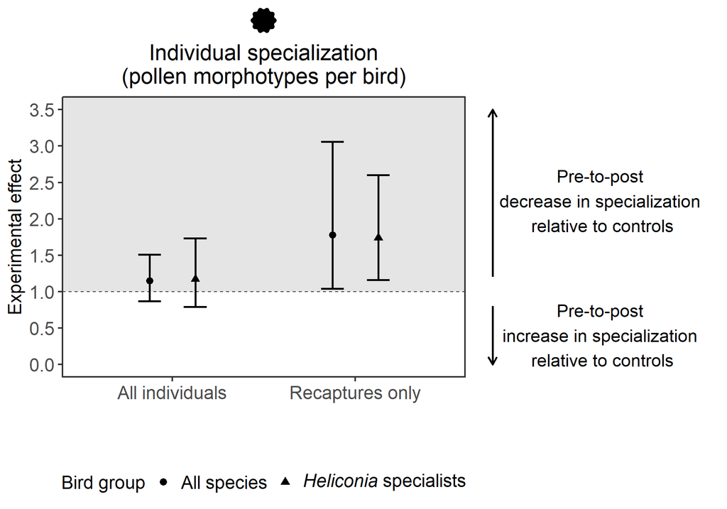

```r
#INDIVIDUAL SPECIALIZATION
contrast_plot_individual <- contrasts_of_contrasts %>%
  filter(analysis == "specialization_individual") %>%
  mutate(subanalysis = factor(subanalysis, levels = c("all_individuals", "recaptures"), labels = c("All individuals\n", "Recaptures only\n"))) %>%
  make_contrast_plot(contrasts_df = ., xvar = "subanalysis", shading = "above") +
    scale_y_continuous(limits = c(0, 3.5), breaks = c(0, 0.5, 1, 1.5, 2, 2.5, 3, 3.5)) +
    coord_cartesian(ylim = c(0, 3.5), xlim = c(1, 2), clip = "off") +
    labs(title = "Individual specialization\n(pollen morphotypes per bird)") +
    theme(legend.position = "bottom",
          plot.margin = unit(c(3, 18, 0.5, 0.5), "lines")) + #Default plot margins in theme_bw are 1, 1, 0.5, 0.5 (top, right, bottom, left)
    annotate("segment", x = 2.75, xend = 2.75, y = 1.2, yend = 3.5, col = "black", size = 1, arrow = arrow(length = unit(0.3, "cm"))) +
    annotate("segment", x = 2.75, xend = 2.75, y = 0.8, yend = 0.0, col = "black", size = 1, arrow = arrow(length = unit(0.3, "cm"))) +
    annotate("text",  x = 3.35, y = 2.25, size = 6, angle = 0, color = "black", label = c("Pre-to-post \ndecrease in specialization \nrelative to controls")) +
    annotate("text",  x = 3.35, y = 0.4, size = 6, angle = 0, color = "black", label = c("Pre-to-post \nincrease in specialization \nrelative to controls")) +
    annotation_custom(rasterGrob(pollen_icon, width = 0.35), xmin = 1, xmax = 2, ymin = 3.5 * 1.65, ymax = Inf)

contrast_plot_individual
```

```r
# ggview(units = "in", width = 10, height = 7)
```

Interaction turnover

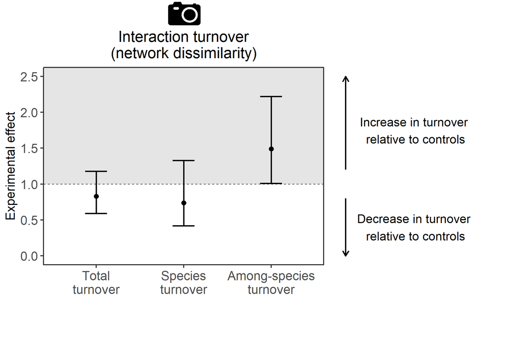

```r
#INTERACTION TURNOVER
contrast_plot_turnover <- contrasts_of_contrasts %>%
  filter(analysis == "turnover" & subanalysis == "binary") %>%
  mutate(yvar = factor(yvar, levels = c("WN", "ST", "OS"), labels = c("Total\nturnover", "Species\nturnover", "Among-species\nturnover"))) %>%
  make_contrast_plot(contrasts_df = ., xvar = "yvar", shading = "above") +
    scale_y_continuous(limits = c(0, 2.5), breaks = c(0, 0.5, 1, 1.5, 2, 2.5)) +
    coord_cartesian(ylim = c(0, 2.5), xlim = c(1, 3), clip = "off") +
    labs(title = "Interaction turnover\n(network dissimilarity)") +
    theme(legend.position = "bottom",
          legend.text = element_text(color = "white"),
          legend.title = element_text(color = "white"),
          plot.margin = unit(c(3, 18, 0.5, 0.5), "lines")) + #Default plot margins in theme_bw are 1, 1, 0.5, 0.5 (top, right, bottom, left)
    annotate("segment", x = 3.85, xend = 3.85, y = 1.2, yend = 2.5, col = "black", size = 1, arrow = arrow(length = unit(0.3, "cm"))) +
    annotate("segment", x = 3.85, xend = 3.85, y = 0.8, yend = 0.0, col = "black", size = 1, arrow = arrow(length = unit(0.3, "cm"))) +
    annotate("text",  x = 4.65, y = 1.75, size = 6, angle = 0, color = "black", label = c("Increase in turnover \nrelative to controls")) +
    annotate("text",  x = 4.65, y = 0.4, size = 6, angle = 0, color = "black", label = c("Decrease in turnover \nrelative to controls")) +
    annotation_custom(rasterGrob(camera_icon, width = 0.35), xmin = 1, xmax = 3, ymin = 2.5 * 1.65, ymax = Inf) +
    scale_shape_discrete(guide = guide_legend(override.aes = list(color = "white")))

contrast_plot_turnover
```

```r
# ggview(units = "in", width = 10, height = 7)
```

Species and network-level specialization

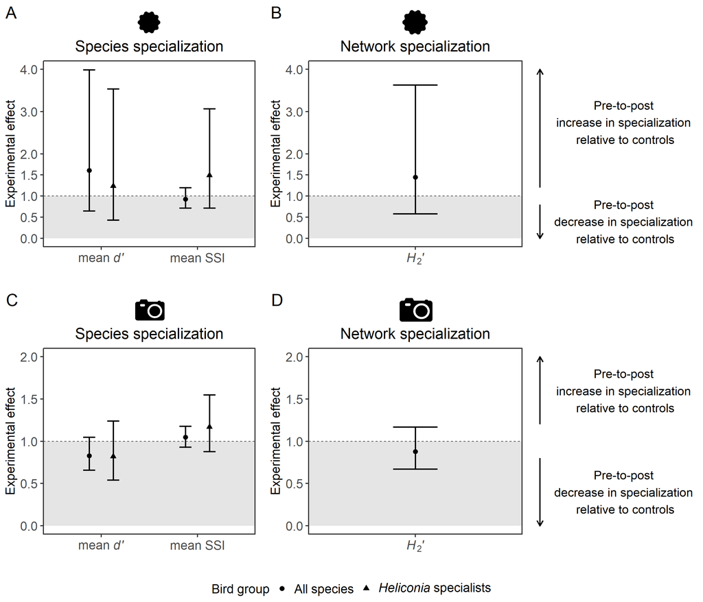

```r
h2_label <- c(expression(paste(italic(H[2])*"′")))
d_label <-  c(expression(paste("mean "*italic(d)*"′")))
ssi_label <- c("mean SSI")

#SPECIES-LEVEL SPECIALIZATION (POLLEN)
contrast_plot_pollen_species <- contrasts_of_contrasts %>%
  filter(analysis == "specialization_network" & (yvar == "d" | yvar == "species.specificity.index") & sampling_method == "pollen") %>%
  make_contrast_plot(contrasts_df = ., xvar = "yvar", shading = "below") +
    scale_x_discrete(labels = c(d_label, ssi_label)) +
    scale_y_continuous(limits = c(0, 4), breaks = c(0, 0.5, 1, 1.5, 2, 3, 4)) +
    coord_cartesian(ylim = c(0, 4), xlim = c(1, 2), clip = "off") +
    labs(title = "Species specialization") +
    theme(legend.position = "bottom", plot.margin = unit(c(4, 1, 0.5, 0.5), "lines")) + #Default plot margins in theme_bw are 1, 1, 0.5, 0.5 (top, right, bottom, left)
    annotation_custom(rasterGrob(pollen_icon, width = 0.35*1.65), xmin = 1, xmax = 2, ymin = 6, ymax = Inf) #Multiply by ggarrange widths to make icons the same size

# contrast_plot_pollen_species
# ggview(units = "in", width = 9, height = 6)

#NETWORK-LEVEL SPECIALIZATION (POLLEN)
contrast_plot_pollen_network <- contrasts_of_contrasts %>%
  filter(analysis == "specialization_network" & yvar == "H2" & sampling_method == "pollen") %>%
  make_contrast_plot(contrasts_df = ., xvar = "yvar", shading = "below") +
    scale_x_discrete(labels = c(h2_label)) +
    scale_y_continuous(limits = c(0, 4), breaks = c(0, 0.5, 1, 1.5, 2, 3, 4)) +
    coord_cartesian(ylim = c(0, 4), xlim = c(1, 1), clip = "off") +
    labs(title = "Network specialization") +
    theme(legend.position = "bottom",
          plot.margin = unit(c(4, 18, 0.5, 0.5), "lines")) + #Default plot margins in theme_bw are 1, 1, 0.5, 0.5 (top, right, bottom, left)
    annotate("segment", x = 1.7, xend = 1.7, y = 1.2, yend = 4.0, col = "black", size = 1, arrow = arrow(length = unit(0.3, "cm"))) +
    annotate("segment", x = 1.7, xend = 1.7, y = 0.8, yend = 0.0, col = "black", size = 1, arrow = arrow(length = unit(0.3, "cm"))) +
    annotate("text",  x = 2.18, y = 2.75, size = 6, angle = 0, color = "black", label = c("Pre-to-post \nincrease in specialization \nrelative to controls")) +
    annotate("text",  x = 2.18, y = 0.4, size = 6, angle = 0, color = "black", label = c("Pre-to-post \ndecrease in specialization \nrelative to controls")) +
    annotation_custom(rasterGrob(pollen_icon, width = 0.35), xmin = 0.5, xmax = 1.5, ymin = 6, ymax = Inf)

# contrast_plot_pollen_network
# ggview(units = "in", width = 9, height = 6)

#SPECIES-LEVEL SPECIALIZATION (CAMERA)
contrast_plot_camera_species <- contrasts_of_contrasts %>%
  filter(analysis == "specialization_network" & (yvar == "d" | yvar == "species.specificity.index") & sampling_method == "camera") %>%
  make_contrast_plot(contrasts_df = ., xvar = "yvar", shading = "below") +
    scale_x_discrete(labels = c(d_label, ssi_label)) +
    scale_y_continuous(limits = c(0, 2.0), breaks = c(0, 0.5, 1, 1.5, 2)) +
    coord_cartesian(ylim = c(0, 2.0), xlim = c(1, 2), clip = "off") +
    labs(title = "Species specialization") +
    theme(legend.position = "bottom",
          plot.margin = unit(c(4, 1, 0.5, 0.5), "lines")) + #Default plot margins in theme_bw are 1, 1, 0.5, 0.5 (top, right, bottom, left)
    annotation_custom(rasterGrob(camera_icon, width = 0.35*1.65), xmin = 1, xmax = 2, ymin = 3, ymax = Inf) #Multiply by ggarrange widths to make icons the same size

# contrast_plot_camera_species
# ggview(units = "in", width = 9, height = 6)

#NETWORK-LEVEL SPECIALIZATION (CAMERA)
contrast_plot_camera_network <- contrasts_of_contrasts %>%
  filter(analysis == "specialization_network" & yvar == "H2" & sampling_method == "camera") %>%
  make_contrast_plot(contrasts_df = ., xvar = "yvar", shading = "below") +
    scale_x_discrete(labels = c(h2_label)) +
    scale_y_continuous(limits = c(0, 2.0), breaks = c(0, 0.5, 1, 1.5, 2)) +
    coord_cartesian(ylim = c(0, 2.0), xlim = c(1, 1), clip = "off") +
    labs(title = "Network specialization") +
    theme(legend.position = "bottom",
          plot.margin = unit(c(4, 18, 0.5, 0.5), "lines")) + #Default plot margins in theme_bw are 1, 1, 0.5, 0.5 (top, right, bottom, left)
    annotate("segment", x = 1.7, xend = 1.7, y = 1.2, yend = 2.0, col = "black", size = 1, arrow = arrow(length = unit(0.3, "cm"))) +
    annotate("segment", x = 1.7, xend = 1.7, y = 0.8, yend = 0.0, col = "black", size = 1, arrow = arrow(length = unit(0.3, "cm"))) +
    annotate("text",  x = 2.18, y = 1.6, size = 6, angle = 0, color = "black", label = c("Pre-to-post \nincrease in specialization \nrelative to controls")) +
    annotate("text",  x = 2.18, y = 0.4, size = 6, angle = 0, color = "black", label = c("Pre-to-post \ndecrease in specialization \nrelative to controls")) +
    annotation_custom(rasterGrob(camera_icon, width = 0.35), xmin = 0.5, xmax = 1.5, ymin = 3, ymax = Inf)

# contrast_plot_camera_network
# ggview(units = "in", width = 9, height = 6)

#Combine (pollen on top, camera on bottom)
contrast_multiplot_species_network <- ggarrange(contrast_plot_pollen_species, contrast_plot_pollen_network, contrast_plot_camera_species, contrast_plot_camera_network,
                                                common.legend = TRUE, legend = "bottom", ncol = 2, nrow = 2, align = "h", labels = "AUTO", font.label = list(size = 24, face = "plain"), widths = c(1, 1.65))
contrast_multiplot_species_network
```

```r
# ggview(units = "in", width = 14, height = 12)
```

## Step 6: Export results

```r
#SUMMARY TABLES
path_name <- c("../results/analyses_experiment/tables")

write.csv(results_tidy_confint, file.path(path_name, "Network_rewiring_results_summary_tables.csv"), row.names = FALSE)
write.csv(sample_size, file.path(path_name, "Network_rewiring_results_sample_size_summary.csv"), row.names = FALSE)
write.csv(emmeans, file.path(path_name,"Network_rewiring_results_emmeans.csv"), row.names = FALSE)
write.csv(contrasts, file.path(path_name,"Network_rewiring_results_contrasts.csv"), row.names = FALSE)
write.csv(contrasts_of_contrasts, file.path(path_name, "Network_rewiring_results_contrasts_of_contrasts.csv"), row.names = FALSE)

#FIGURES
path_name <- c("../results/analyses_experiment/figures")

#Interaction plots
ggsave(file.path(path_name, "Interaction_multiplot_species_and_network_all.png"), interaction_multiplot_species_network_all, dpi = 300, units = "in", width = 9, height = 12, bg = "white")
ggsave(file.path(path_name, "Interaction_multiplot_species_and_network_gv.png"), interaction_multiplot_species_network_gv, dpi = 300, units = "in", width = 9, height = 9, bg = "white")
ggsave(file.path(path_name, "Interaction_multiplot_individual.png"), interaction_multiplot_individual, dpi = 300, units = "in", width = 9, height = 9, bg = "white")

#Contrast plots
ggsave(file.path(path_name, "Contrast_individual.png"), contrast_plot_individual, dpi = 300, units = "in", width = 10, height = 7, bg = "white")
ggsave(file.path(path_name, "Contrast_turnover.png"), contrast_plot_turnover, dpi = 300, units = "in", width = 10, height = 7, bg = "white")
ggsave(file.path(path_name, "Contrast_multiplot_species_and_network.png"), contrast_multiplot_species_network, dpi = 300, units = "in", width = 14, height = 12, bg = "white")
```